# Part II - Ford GoBike Trip Durations, User Type and Genders

## by Abd Al-Muttalib Ibreighith

## Investigation Overview

The goal of the investigation is to analyze the Ford GoBike System data, focusing on trip durations, user types, bike-sharing behavior, and demographic information. Key insights are derived from exploring these aspects and visualizing the data to identify trends and patterns.

## Dataset Overview and Executive Summary

The dataset contains information on bike trips, including trip durations, user types (Customer or Subscriber), bike-sharing behavior, member birth years, and other relevant details. Key findings include:

- **Trip Duration:** Most trips are short, with a significant number lasting less than 1,000 seconds. However, there are outliers with very long durations.
- **User Types:** Subscribers constitute the majority of users compared to Customers.
- **Bike Sharing:** Most users do not share their bikes for the entire trip.
- **Member Birth Years:** The majority of members were born between 1960 and 1990.

These findings provide a basis for deeper analysis into user behavior and system usage patterns.

### Visualizations in Part I

1. **Distribution of Trip Durations:** Shows most trips are under 1,000 seconds, with a long tail for longer trips.
2. **Distribution of User Types:** Highlights the dominance of Subscribers over Customers.
3. **Riders Who Shared Their Bikes vs. Didn't Share:** Indicates that most riders did not share their bikes for the entire trip.
4. **Distribution of Member Birth Years:** Shows a concentration of birth years between 1960 and 1990.

```python
# import all packages and set plots to be embedded inline
import numpy as np
import pandas as pd
import matplotlib.pyplot as plt
import seaborn as sns

# suppress warnings from final output
import warnings
warnings.simplefilter("ignore")
```

```python
# load in the dataset into a pandas dataframe
df_clean = pd.read_csv('201902-fordgobike-tripdata-cleaned.csv')
```

```python
# Correct start_time and end_time datatypes into datetime type
df_clean['start_time'] = pd.to_datetime(df_clean['start_time'])
df_clean['end_time'] = pd.to_datetime(df_clean['end_time'])

# Correct ids datatypes into int64
df_clean['start_station_id'] = df_clean['start_station_id'].astype('int64')
df_clean['end_station_id'] = df_clean['end_station_id'].astype('int64')

# Correct member_birth_year datatype into int64
df_clean['member_birth_year'] = df_clean['member_birth_year'].astype('int64')
```

## Visualization 1: Distribution of Trip Durations

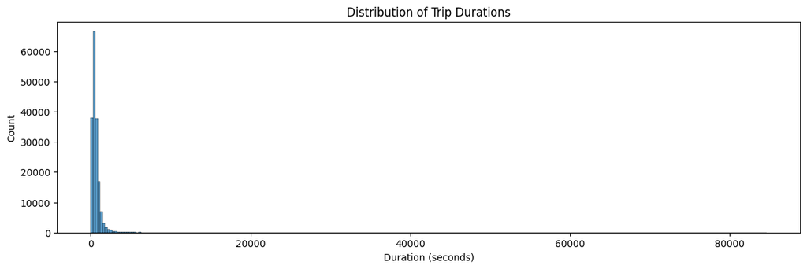

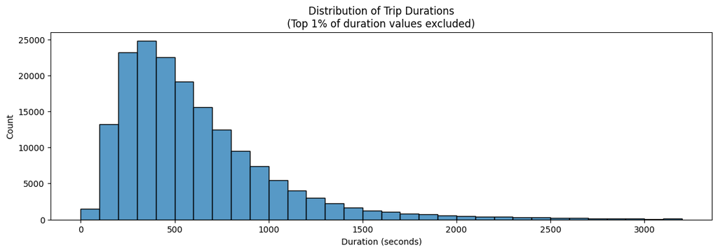

```python
# Plot the histogram for trip durations
plt.figure(figsize=(14, 4))
binsize = 300
bins = np.arange(0, df_clean['duration_sec'].max() + binsize, binsize)

sns.histplot(df_clean['duration_sec'], bins=bins)
plt.title('Distribution of Trip Durations')
plt.xlabel('Duration (seconds)')
plt.ylabel('Count')
plt.show()

# Plot the histogram for trip durations excluding outliers
plt.figure(figsize=(14, 4))
binsize = 100
bins = np.arange(0, df_clean['duration_sec'].quantile(0.99) + binsize, binsize)

sns.histplot(df_clean['duration_sec'], bins=bins)
plt.title('Distribution of Trip Durations\n(Top 1% of duration values excluded)')
plt.xlabel('Duration (seconds)')
plt.ylabel('Count')
plt.show()
```

## Visualization 2: The average duration of bike trips vary across different days of the week

Bike trips are notably longer on weekends, suggesting people take leisure trips then. Also, Weekday trips are shorter and consistent, indicating routine or commuting-focused travel.

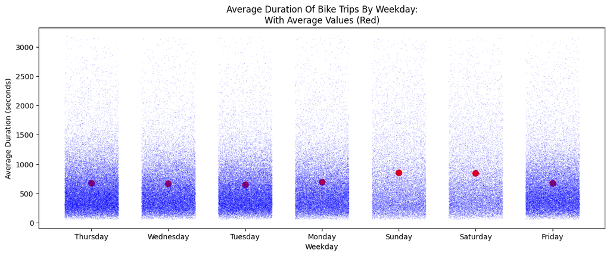

```python
# Extract the weekday from start_time
df_clean['weekday'] = df_clean['start_time'].dt.day_name()

# Calculate the average duration per weekday
avg_duration_per_weekday = df_clean.groupby('weekday')['duration_sec'].mean().reset_index()

# Ensure the weekdays are in the correct order
weekday_order = ['Monday', 'Tuesday', 'Wednesday', 'Thursday', 'Friday', 'Saturday', 'Sunday']
avg_duration_per_weekday['weekday'] = pd.Categorical(avg_duration_per_weekday['weekday'], categories=weekday_order, ordered=True)
avg_duration_per_weekday = avg_duration_per_weekday.sort_values('weekday')

# Plot the data
# create the first axes
fig, ax = plt.subplots(nrows=1, ncols=1, figsize=[14, 5])

sns.stripplot(data = df_clean.query('duration_sec<duration_sec.quantile(0.99)'), x='weekday', y = 'duration_sec',
              color='b', size=1,jitter=0.35, ax=ax, alpha=0.2)

sns.scatterplot(data = avg_duration_per_weekday, x = 'weekday', y = 'duration_sec', s=100, color='red', ax=ax)
plt.title('Average Duration Of Bike Trips by Weekday:\nWith Average values (Red)'.title())
plt.xlabel('Weekday')
plt.ylabel('Average Duration (seconds)')
```

## Visualization 3: Relationship between trip duration and age, categorized by bike share status

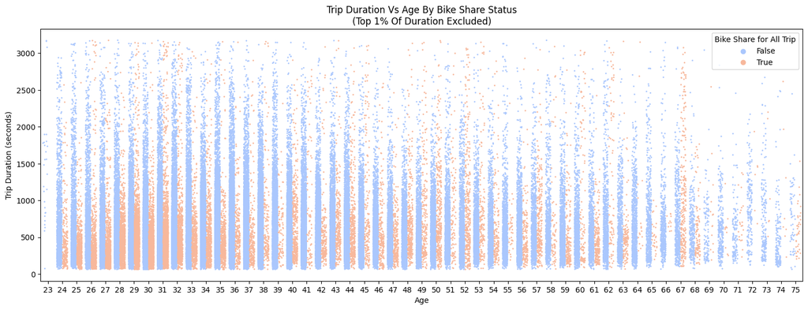

```python
df_clean['age'] = 2024 - df_clean['member_birth_year']  # Assuming current year is 2024

# Plot
plt.figure(figsize=(18, 6))
sns.stripplot(data=df_clean.query('duration_sec<duration_sec.quantile(0.99) and age<=75'),
              x='age', y='duration_sec', hue='bike_share_for_all_trip', palette='coolwarm',
              size=2, jitter=0.35, dodge=True)
plt.xlabel("Age")
plt.ylabel("Trip Duration (seconds)")
plt.title("Trip Duration vs Age by Bike Share Status\n(Top 1% of duration excluded)".title())
plt.legend(title='Bike Share for All Trip')
plt.show()
```

### Conclusion:

These visualizations provide insights into user behavior and demographics in the Ford GoBike System. The findings suggest that most trips are short, the majority of users are subscribers, and bike sharing is not common. Additionally, the service is predominantly used by individuals born between 1960 and 1990. These insights can help inform strategies to improve the bike-sharing service and address user needs.